# Location & Date reporting bias

## Rates of missing observations by variable

Resourcing Unit: 0%

Actual Work: 0%

Shift: 0%

Cancellation Reason: 0%

Cancellation Lead Time: 0%

Actual Start: 0%

Actual End: 0%

Is Cancelled: 0%

Actual Rest: 0%

Is Additional: 0%

Is Optional: 0%

Assigned By: 0%

Has Warnings: 0%

Payroll State: 0%

Location Type: 0%

Location: 0%

Cost Centre: 0%

Resource Requirement: 0%

Required Team: 0%

Required Grade: 0%

Required Grade Type: 0%

Required Grade Type Category: 0%

Fulfilment Type: 0%

Dissection Type: 0%

Posting Org Unit: 0%

Shift Type: 0%

Post: 0%

Assignment No: 0.703%

Contract: 79.099%

Grade: 79.104%

Planned Start: 0.004%

Planned End: 0.885%

Planned Work: 0.885%

Activity Type: 0%

Activity Benchmark: 0%

Activity Category: 0%

Activity Profile: 0%

Activity Profile Short Name: 0%

PA Value: 0%

Assigned Primary Person: 0%

Supervised: 0%

Reason: 0%

Total Duty Cost: 0%

Exclude from NHPPD: 0%

Is Assignment Change: 0%

Is Standby: 0%

Supplying Agency: 0%

Clock In: 0%

Clock Out: 0%

Clock Work Time: 99.109%

Clock Events Count: 0.006%

Pay Flag Categories: 99.109%

Pay Flags: 100%

Device ID: 0.006%

Cancellation Date: 99.994%

Cancellation Time: 99.109%

## Summary of predictability of missing patterns based on location or date

Predictability is measured via the ROC, which ranges from 0.5 to 1, with 1 implying perfect predictability. Data was divided into training and validation sets - so ROC represents predicatbility on data unseen during training. Value of > 0.8 may be cuase for concern (see the figures that follow for interpretation of models).

ROC-AUC values for location and date models.

| Var | DateROC | LocROC |
| --- | --- | --- |
| Assignment No | 0.517 | 0.725 |
| Planned End | 0.599 | 0.737 |
| Planned Work | 0.569 | 0.737 |

## Duty Date on Missing

Figures to summarize Date on missing bias.

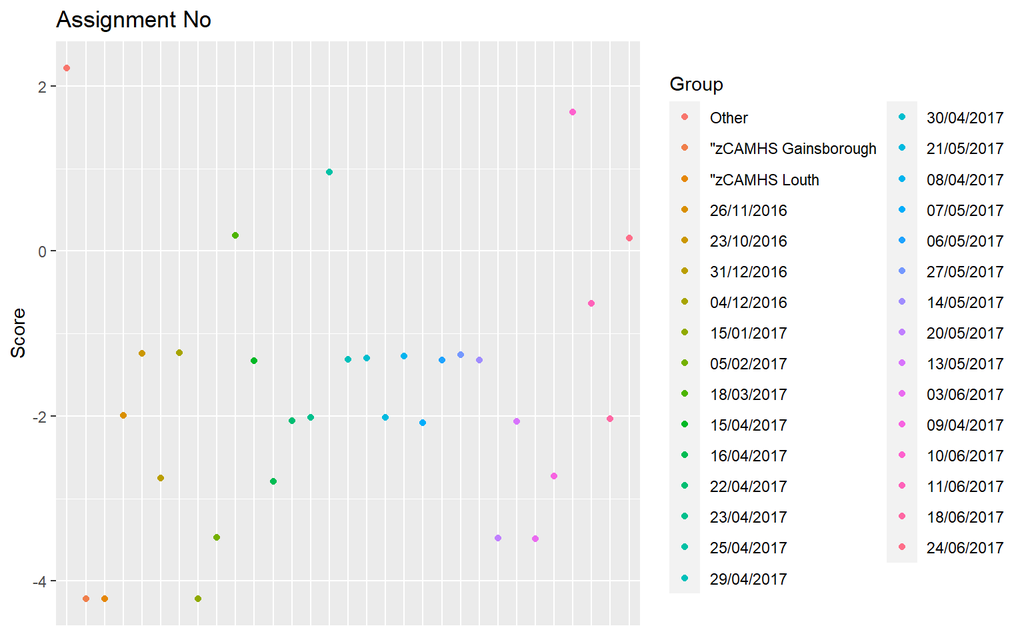

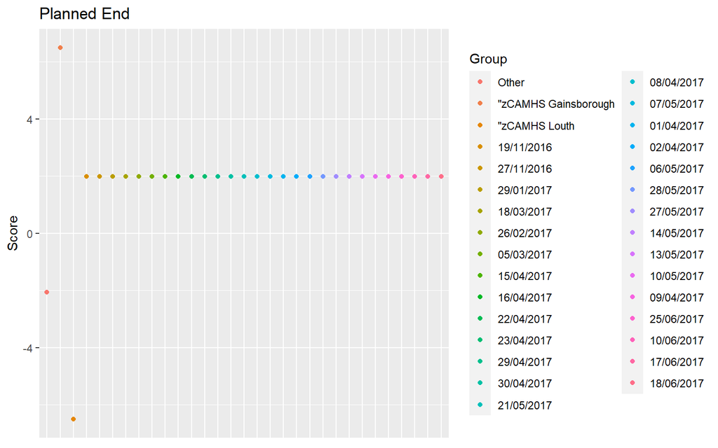

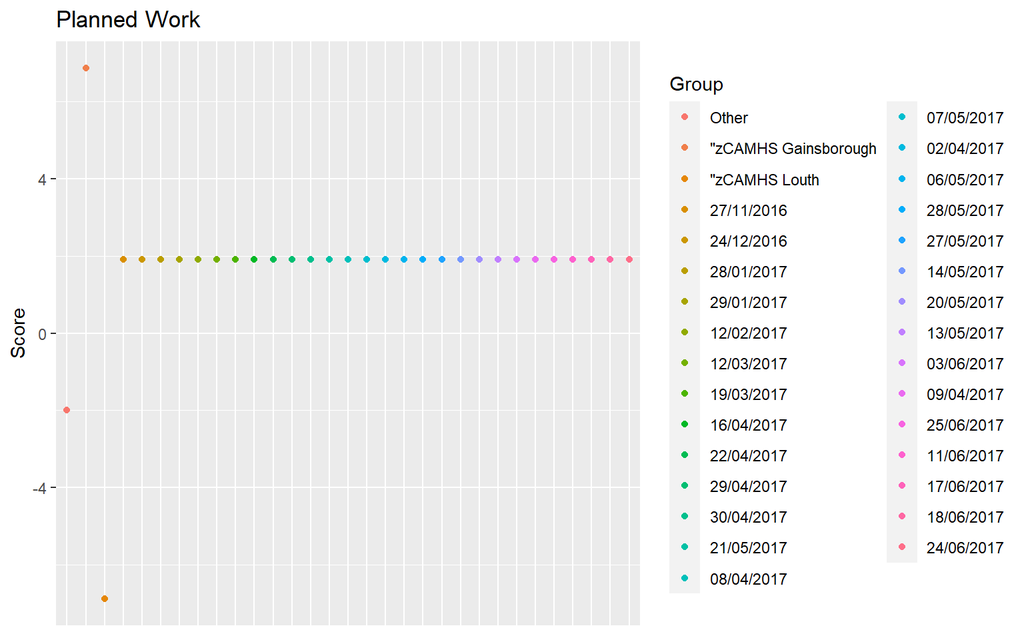

## Owning Unit on Missing

Figures to summarize Location on missing bias.

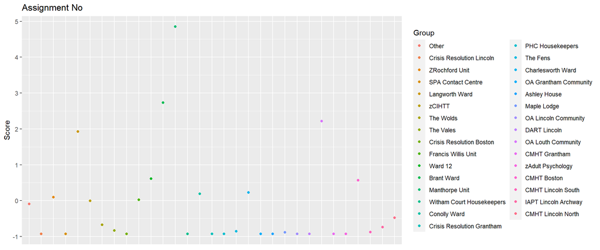

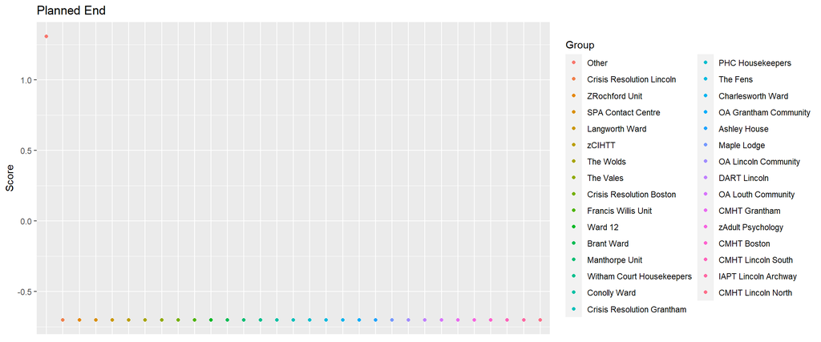

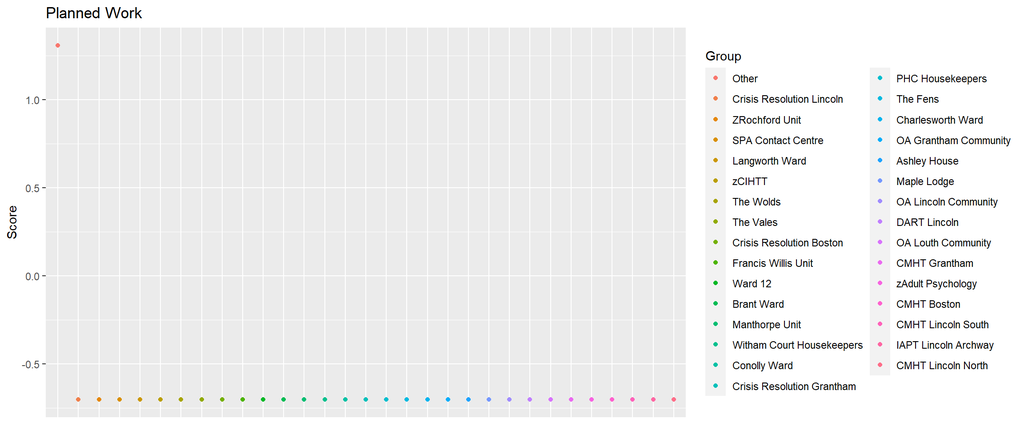